# Multiple Linear Regression

Applied Statistics

MTH-361A | Spring 2025 | University of Portland

April 14, 2025

# Objectives

- **Introduce multiple linear regression**
- **Develop an understanding on how to apply and assess a multiple linear regression model**
- **Know how to conduct multiple linear regression in R**
- **Activity: Selecting Variables for Multiple Linear Regression**

# Previously… (1/2)

**Linear Regression**

$$y = \beta_0 + \beta_1 x +
\epsilon$$

- $y$ is the outcome, $x$ is the predictor, $\beta_0$ is the intercept, and $\beta_1$ is the slope. The notation $\epsilon$ is the model’s error (residuals).
- We estimate the slope $b_1$ and intercept $b_0$ of the least squares regression line by minimizing the sum of squared residuals.
- The slope is given by $b_1 = \frac{s_y}{s_x} r$ , and the intercept is $b_0 = \bar{y} - b_1 \bar{x}$ , where $r$ is the correlation coefficient, $s_x$ and $s_y$ are the standard deviations of $x$ and $y$, and $\bar{x}$, $\bar{y}$ are their respective means.

# Previously… (2/2)

**Confidence Intervals for Linear Regression**

$$\begin{aligned}
\text{slope } \longrightarrow b_1 \pm t_{df}^* \text{SE}_{b_1} \\
\text{intercept } \longrightarrow b_0 \pm t_{df}^* \text{SE}_{b_0}
\end{aligned}$$

**Hypothesis testing for Linear Regression**

# Case Study I

Housing sales data from King County, WA, which includes the city of Seattle. The data `houses` in the `fosdata` package contains a record of every house sold in King County from May 2014 to May 2015.

There are 21,613 houses in total with 21 variables. Below is a random sample of 4 houses with select variables.

```
## # A tibble: 4 × 9
##   zipcode  price bedrooms bathrooms sqft_living sqft_lot floors condition grade
##     <int>  <dbl>    <int>     <dbl>       <int>    <int>  <dbl>     <int> <int>
## 1   98042 208000        3      2           1250     7995    1           4     7
## 2   98027 588000        4      2.25        2580     7344    2           3     8
## 3   98010 325000        4      1.5         1470    70800    1           3     7
## 4   98109 740000        4      2.75        2890     4000    1.5         4     9
```

# Case Study I: Subset

In this example, we only look at the houses that is located on the specific zipcode of 98115. This reduced the data set to 583 houses. Below, we show 4 random samples with select variables.

```
## # A tibble: 4 × 9
##         id  price bedrooms bathrooms sqft_living sqft_lot floors condition grade
##      <dbl>  <dbl>    <int>     <dbl>       <int>    <int>  <dbl>     <int> <int>
## 1   1.03e8 645000        3      1.75        2070     5500      1         4     7
## 2   6.39e9 433500        3      1           1230     6000      1         4     7
## 3   5.10e9 450000        2      1           1380     4390      1         4     8
## 4   5.10e9 445000        4      2.5         2170     5257      2         3     7
```

# Case Study I: Data Exploration (1/3)

Exploring the data. Our focus is to look at the `price`, `sqft_living`, and `sqft_lot` variables.

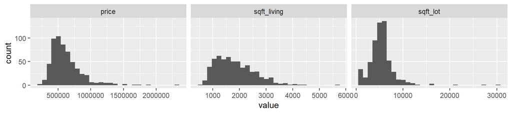

The variables appears to be moderately right-skewed.

# Case Study I: Data Exploration (2/3)

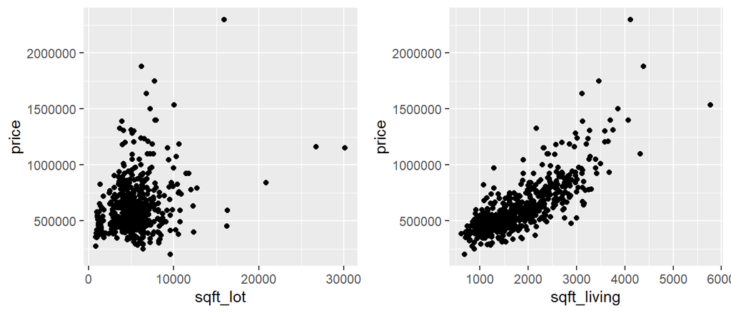

# Case Study I: Data Exploration (3/3)

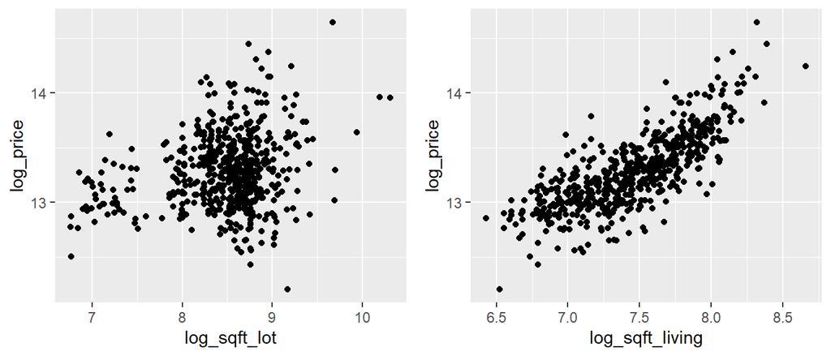

# Case Study I: The Multiple Linear Regression Model (1/2)

$$y = \beta_0 + \beta_1 x_1 + \beta_2 x_2
+ \epsilon$$

where $\beta_0$ is the intercept, $\beta_1$ and $\beta_2$ are the coefficients (slopes) of the explanatory variables.

# Case Study I: The Multiple Linear Regression Model (2/2)

$$\hat{y} = b_0 + b_1 x_1 + b_2 x_2 +
\epsilon$$

```r
mlr_mod <- lm(log_price ~ log_sqft_living + log_sqft_lot, data = log_houses)
summary(mlr_mod)
```

```
##
## Call:
## lm(formula = log_price ~ log_sqft_living + log_sqft_lot, data = log_houses)
##
## Residuals:
##      Min       1Q   Median       3Q      Max
## -0.62790 -0.12085 -0.00189  0.12904  0.75567
##
## Coefficients:
##                 Estimate Std. Error t value Pr(>|t|)
## (Intercept)      8.14199    0.19922   40.87   <2e-16 ***
## log_sqft_living  0.65130    0.02303   28.29   <2e-16 ***
## log_sqft_lot     0.03422    0.01755    1.95   0.0517 .
## ---
## Signif. codes:  0 '***' 0.001 '**' 0.01 '*' 0.05 '.' 0.1 ' ' 1
##
## Residual standard error: 0.211 on 580 degrees of freedom
## Multiple R-squared:  0.6021, Adjusted R-squared:  0.6007
## F-statistic: 438.8 on 2 and 580 DF,  p-value: < 2.2e-16
```

We ignore most of the output for now and focus on the estimates of the coefficients. Namely, $b_0 = 8.14199$, $b_1 = 0.65130$, and $b_2 = 0.03422$.

# Assesing the Multiple Linear Regression Model

The **R-squared** is the a measure of how well the simple linear regression fits the data but this is a biased estimate of the amount of variability explained by the model when applied to model with more than one predictor.

$$R^2 = 1 - \frac{SSE}{SST}$$

The **adjusted R-squared** describes the power of the regression model that contain different numbers of predictors.

This is computed as

$$\begin{aligned}
R_{adj}^{2}
&= 1 - \frac{s_{\text{residuals}}^2 / (n-k-1)}
{s_{\text{outcome}}^2 / (n-1)} \\
&= 1 - \frac{s_{\text{residuals}}^2}{s_{\text{outcome}}^2}
\times \frac{n-1}{n-k-1}
\end{aligned}$$

where $n$ is the number of observations used to fit the model and $k$ is the number of predictor variables in the model.

# Activity: Selecting Variables for Multiple Linear Regression

1. Log-in to Posit Cloud and open the R Studio assignment *M 4/14 - Selecting Variables for Multiple Linear Regression*.
2. Make sure you are in the current working directory. Rename the `.Rmd` file by replacing `[name]` with your name using the format `[First name][Last initial]`. Then, open the `.Rmd` file.
3. Change the author in the YAML header.
4. Read the provided instructions.
5. Answer all exercise problems on the designated sections.

# References

Diez, D. M., Barr, C. D., & Çetinkaya-Rundel, M. (2012). *OpenIntro statistics* (4th ed.). OpenIntro. https://www.openintro.org/book/os/

Speegle, Darrin and Clair, Bryan. (2021). *Probability, statistics, and data: A fresh approach using r*. Chapman; Hall/CRC. https://probstatsdata.com/